# New_IP

Farnadis_Kanja

1/24/2022

```r
library("readr")
```

```r
kanja <- read.csv("kanja.csv")
head(kanja)
```

```
##   Daily.Time.Spent.on.Site Age Area.Income Daily.Internet.Usage
## 1                    68.95  35    61833.90               256.09
## 2                    80.23  31    68441.85               193.77
## 3                    69.47  26    59785.94               236.50
## 4                    74.15  29    54806.18               245.89
## 5                    68.37  35    73889.99               225.58
## 6                    59.99  23    59761.56               226.74
##                           Ad.Topic.Line           City Male    Country
## 1    Cloned 5thgeneration orchestration    Wrightburgh    0    Tunisia
## 2    Monitored national standardization      West Jodi    1      Nauru
## 3      Organic bottom-line service-desk       Davidton    0 San Marino
## 4 Triple-buffered reciprocal time-frame West Terrifurt    1      Italy
## 5         Robust logistical utilization   South Manuel    0    Iceland
## 6       Sharable client-driven software      Jamieberg    1     Norway
##             Timestamp Clicked.on.Ad
## 1 2016-03-27 00:53:11             0
## 2 2016-04-04 01:39:02             0
## 3 2016-03-13 20:35:42             0
## 4 2016-01-10 02:31:19             0
## 5 2016-06-03 03:36:18             0
## 6 2016-05-19 14:30:17             0
```

Let’s Preview the dataset

```r
summary(kanja)
```

```
##  Daily.Time.Spent.on.Site      Age         Area.Income    Daily.Internet.Usage
##  Min.   :32.60            Min.   :19.00   Min.   :13996   Min.   :104.8
##  1st Qu.:51.36            1st Qu.:29.00   1st Qu.:47032   1st Qu.:138.8
##  Median :68.22            Median :35.00   Median :57012   Median :183.1
##  Mean   :65.00            Mean   :36.01   Mean   :55000   Mean   :180.0
##  3rd Qu.:78.55            3rd Qu.:42.00   3rd Qu.:65471   3rd Qu.:218.8
##  Max.   :91.43            Max.   :61.00   Max.   :79485   Max.   :270.0
##
##                                  Ad.Topic.Line              City
##  Adaptive 24hour Graphic Interface      :  1   Lisamouth      :  3
##  Adaptive asynchronous attitude         :  1   Williamsport   :  3
##  Adaptive context-sensitive application :  1   Benjaminchester:  2
##  Adaptive contextually-based methodology:  1   East John      :  2
##  Adaptive demand-driven knowledgebase   :  1   East Timothy   :  2
##  Adaptive uniform capability            :  1   Johnstad       :  2
##  (Other)                                :994   (Other)        :986
##       Male                 Country                  Timestamp   Clicked.on.Ad
##  Min.   :0.000   Czech Republic:  9   2016-01-01 02:52:10:  1   Min.   :0.0
##  1st Qu.:0.000   France        :  9   2016-01-01 03:35:35:  1   1st Qu.:0.0
##  Median :0.000   Afghanistan   :  8   2016-01-01 05:31:22:  1   Median :0.5
##  Mean   :0.481   Australia     :  8   2016-01-01 08:27:06:  1   Mean   :0.5
##  3rd Qu.:1.000   Cyprus        :  8   2016-01-01 15:14:24:  1   3rd Qu.:1.0
##  Max.   :1.000   Greece        :  8   2016-01-01 20:17:49:  1   Max.   :1.0
##                  (Other)       :950   (Other)            :994
```

Let’s look at the length of the dataset

```r
length(kanja)
```

```
## [1] 10
```

```r
dim(kanja)
```

```
## [1] 1000   10
```

This dataset has 1000 rows and 10 columns We now need to identify the names of the colums

```r
colnames(kanja)
```

```
##  [1] "Daily.Time.Spent.on.Site" "Age"
##  [3] "Area.Income"              "Daily.Internet.Usage"
##  [5] "Ad.Topic.Line"            "City"
##  [7] "Male"                     "Country"
##  [9] "Timestamp"                "Clicked.on.Ad"
```

Let us now identify datatypes

```r
sapply(kanja,class)
```

```
## Daily.Time.Spent.on.Site                      Age              Area.Income
##                "numeric"                "integer"                "numeric"
##     Daily.Internet.Usage            Ad.Topic.Line                     City
##                "numeric"                 "factor"                 "factor"
##                     Male                  Country                Timestamp
##                "integer"                 "factor"                 "factor"
##            Clicked.on.Ad
##                "integer"
```

We need to change the timestamp to date

```r
kanja$Timestamp <-as.Date(kanja$Timestamp, format = "%Y-%m-%s-%h-%m -%s")
#checking if the change has been implemented
sapply(kanja,class)
```

```
## Daily.Time.Spent.on.Site                      Age              Area.Income
##                "numeric"                "integer"                "numeric"
##     Daily.Internet.Usage            Ad.Topic.Line                     City
##                "numeric"                 "factor"                 "factor"
##                     Male                  Country                Timestamp
##                "integer"                 "factor"                   "Date"
##            Clicked.on.Ad
##                "integer"
```

Univariate Analysis Let’s begin with daily time spent on site

```r
mean(kanja$Daily.Time.Spent.on.Site)
```

```
## [1] 65.0002
```

```r
median(kanja$Daily.Time.Spent.on.Site)
```

```
## [1] 68.215
```

```r
#mode
y <- kanja$Daily.Time.Spent.on.Site
names(table(y))[table(y)==max(table(y))]
```

```
## [1] "62.26" "75.55" "77.05" "78.76" "84.53"
```

The numbers above are the ones that most frequently appear on the dataset Let’s check the distribution using a histogram

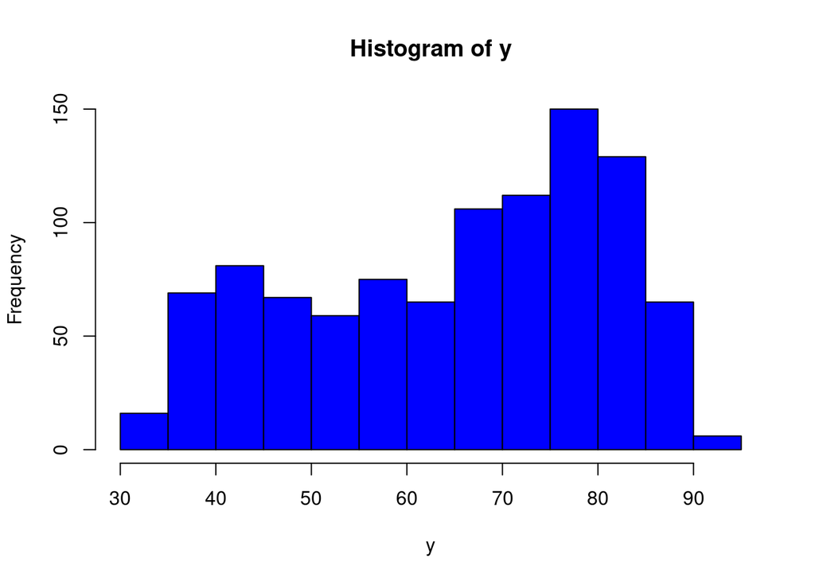

```r
hist(y, col=c("blue"))
```

The mean time spent on the site is 65.0002 The median is 68.215 The time that appears most commonly is 62.26,75.55,77.05,78.76,84.53 As we can see the distribution is left-skewed.

*Age*

```r
mean(kanja$Age)
```

```
## [1] 36.009
```

```r
median(kanja$Age)
```

```
## [1] 35
```

```r
#mode
k <- kanja$Age
#names(table(k))[table(k)==max(table(k))]
```

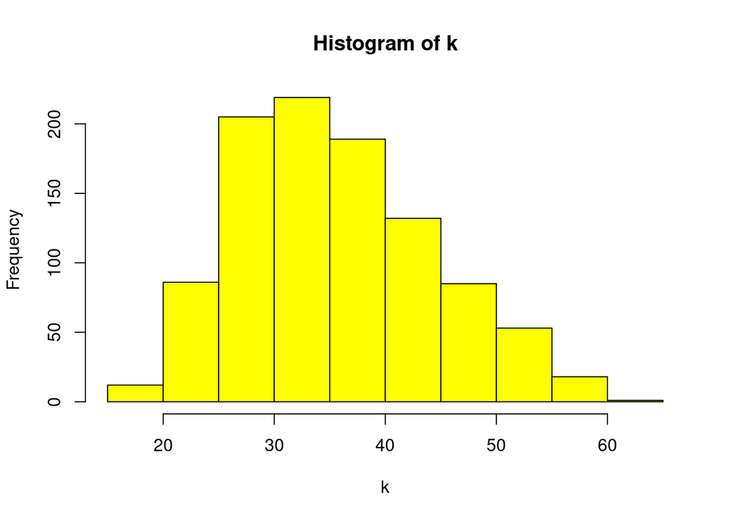

```r
hist(k, col=c("yellow"))
```

```r
mean(kanja$Area.Income)
```

```
## [1] 55000
```

```r
median(kanja$Area.Income)
```

```
## [1] 57012.3
```

```r
t <- kanja$Area.Income
#names(table(m))[table(m)==max(table(m))]
```

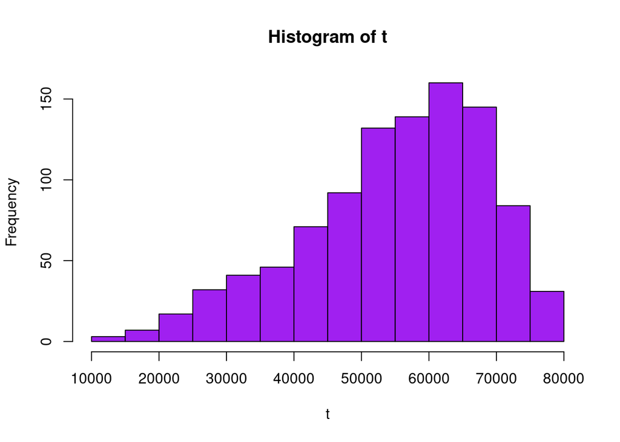

```r
hist(t, col=c("purple"))
```

```r
mean(kanja$Daily.Internet.Usage)
```

```
## [1] 180.0001
```

```r
median(kanja$Daily.Internet.Usage)
```

```
## [1] 183.13
```

```r
s <- kanja$Daily.Internet.Usage
```

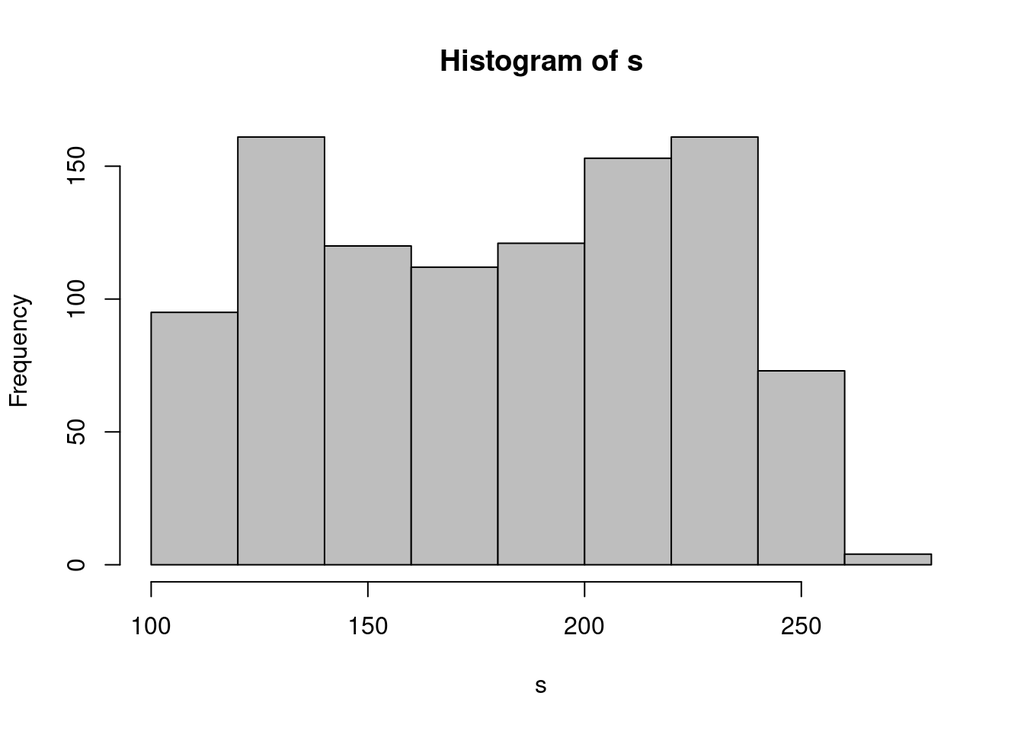

```r
hist(s,col = c("grey"))
```

```r
male <- table(kanja$Male)
```

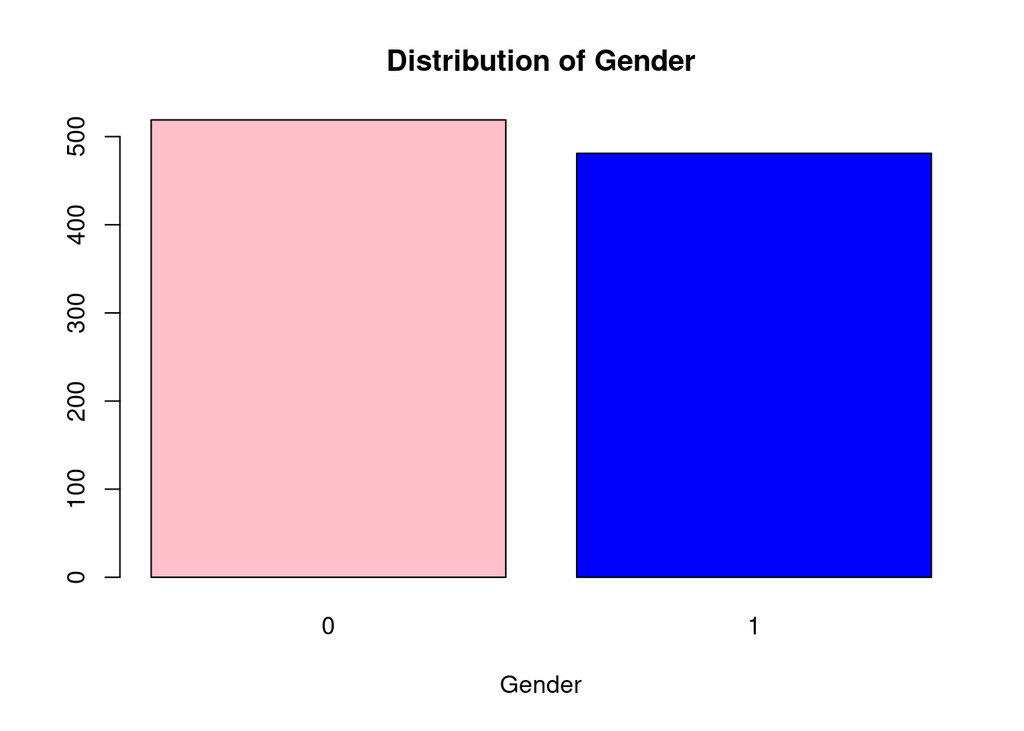

```r
barplot(male, main="Distribution of Gender", col = c("pink","blue"),xlab="Gender")
```

There is an almost equal distribution of the genders although there are slightly more women than men. *City* #Let’s see how many cities are in the data set

```r
length(levels(kanja$City))
```

```
## [1] 969
```

There is a total of 969 cities in the dataset

```r
c <-kanja$City
```

```r
sort(c)
```

[output not shown]

[output cut: 320 more lines]

```r
names(table(c))[table(c)==max(table(c))]
```

```
## [1] "Lisamouth"    "Williamsport"
```

The two most popular cities are Lisamouth and Williamsport *Country* #Let’s see how many countries there are in the dataset

```r
length(levels(kanja$Country))
```

```
## [1] 237
```

There are 237 countries in the dataset

```r
a <-kanja$Country
```

```r
sort(a)
```

[output not shown]

[output cut: 986 more lines]

```r
names(table(a))[table(a)==max(table(a))]
```

```
## [1] "Czech Republic" "France"
```

Czech Republic and France are the two most popular countries

*Clicked on Ad* The viewers either clicked on ad or they did not

```r
clicked <- table(kanja$Clicked.on.Ad)
```

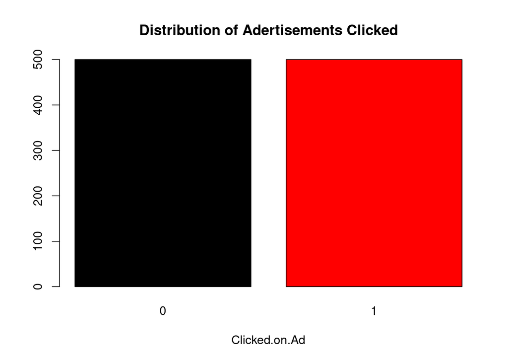

```r
barplot(clicked, main="Distribution of Adertisements Clicked", col = c("black","red"),xlab="Clicked.on.Ad")
```

There seems to be an equal distribution of those who clicked on an advertisement and those who did not. There were 500 unique values

*Bivariate Analysis* We shall begin by dropping the topic line for ad as it seems to serve no purpose. df2 <- subset(kanja, select = c (Daily.Time.Spent.on.Site, Age,Area.Income,Daily.Internt.Usage,Male,Clicked.on.Ad))

```r
df2 <- subset(kanja, select = c (Daily.Time.Spent.on.Site, Age,Area.Income,Daily.Internet.Usage,Male,Clicked.on.Ad))
```

```r
head(df2)
```

```
##   Daily.Time.Spent.on.Site Age Area.Income Daily.Internet.Usage Male
## 1                    68.95  35    61833.90               256.09    0
## 2                    80.23  31    68441.85               193.77    1
## 3                    69.47  26    59785.94               236.50    0
## 4                    74.15  29    54806.18               245.89    1
## 5                    68.37  35    73889.99               225.58    0
## 6                    59.99  23    59761.56               226.74    1
##   Clicked.on.Ad
## 1             0
## 2             0
## 3             0
## 4             0
## 5             0
## 6             0
```

For correlation, let’s use Pearsons

```r
mydata=cor(df2,method = c("pearson"))
```

```r
mydata
```

```
##                          Daily.Time.Spent.on.Site         Age  Area.Income
## Daily.Time.Spent.on.Site               1.00000000 -0.33151334  0.310954413
## Age                                   -0.33151334  1.00000000 -0.182604955
## Area.Income                            0.31095441 -0.18260496  1.000000000
## Daily.Internet.Usage                   0.51865848 -0.36720856  0.337495533
## Male                                  -0.01895085 -0.02104406  0.001322359
## Clicked.on.Ad                         -0.74811656  0.49253127 -0.476254628
##                          Daily.Internet.Usage         Male Clicked.on.Ad
## Daily.Time.Spent.on.Site           0.51865848 -0.018950855   -0.74811656
## Age                               -0.36720856 -0.021044064    0.49253127
## Area.Income                        0.33749553  0.001322359   -0.47625463
## Daily.Internet.Usage               1.00000000  0.028012326   -0.78653918
## Male                               0.02801233  1.000000000   -0.03802747
## Clicked.on.Ad                     -0.78653918 -0.038027466    1.00000000
```

```r
library(ggplot2)
```

[figure not shown]

```r
ggplot(mpg,
       aes (x = "Male",
       fill = "Clicked.on.Ad"==1,)) +
  geom_bar(position = "dodge")
```